# MODFLOW validation

Gopal Penny

7/11/2020

# 1 Prepare anem scenario

We first need to rotate the transform the coordinate system so that the boundaries are horizontal and vertical. The original wells and new wells look like the following.

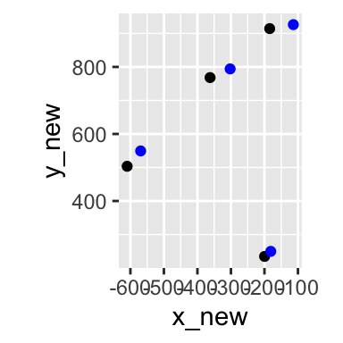

```r
aquifer <- gw_anem$aquifer
aq_bounds <- gw_anem$aquifer$bounds %>% sf::st_set_geometry(NULL) %>% filter(bound_type!="PB")
wells <- gw_anem$wells %>% filter(well_image=="Actual") %>% select(wID,Q,R,diam,x,y) %>% sf::st_set_geometry(NULL)

wells_transformed <- wells %>% rename(x_well=x,y_well=y) %>% bind_cols(get_nearest_point_on_line(wells,aq_bounds$m[1],aq_bounds$b[1])) %>%
  mutate(y_new=sqrt((x-x_well)^2+(y-y_well)^2)) %>% select(-x,-y) %>% bind_cols(get_nearest_point_on_line(wells,aq_bounds$m[2],aq_bounds$b[2])) %>%
  mutate(x_new=-sqrt((x-x_well)^2+(y-y_well)^2)) %>% select(-x,-y)

ggplot(wells_transformed) +
  geom_point(aes(x_new,y_new)) +
  geom_point(aes(x_well-403015,y_well-3488056),color="blue") +
  # geom_segment(data=aquifer$bounds,aes(x1,y1,xend=x2,yend=y2,color=bound_type)) +
  coord_equal()
```

We then fix the coordinates such that the constant head boundary is at y = 0 and the no flow boundary is at x = 800. The coordinate system is in meters.

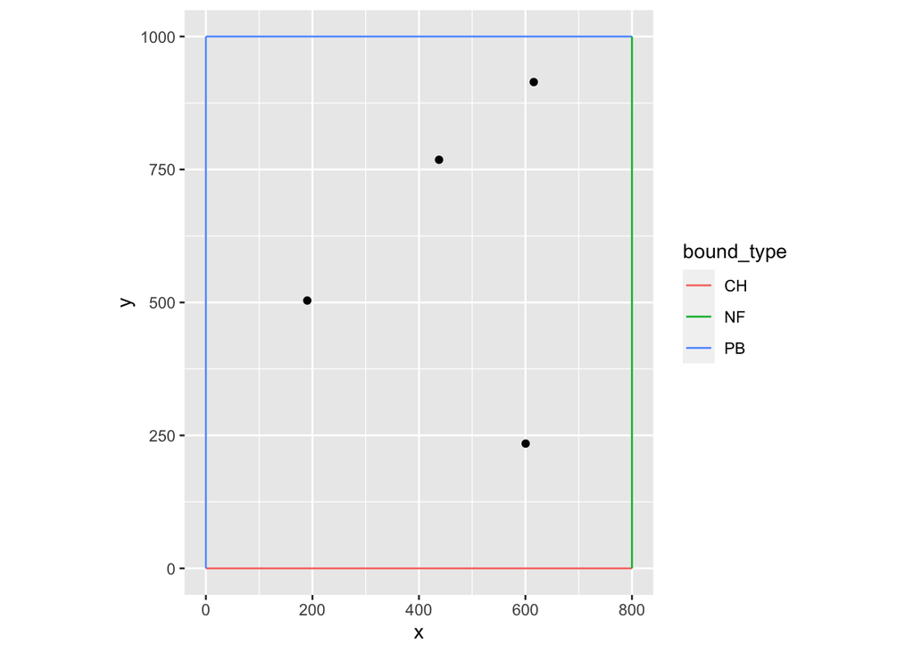

```r
bounds_transformed_df <- tibble(m=c(0,Inf,0,Inf),b=c(0,0,1000,800),bound_type=c("CH","PB","PB","NF"))
aquifer$bounds <- define_bounds(bounds_transformed_df)
aquifer$recharge <- NULL

wells_new <- wells_transformed %>% mutate(x = x_new + 800) %>% select(wID, Q, R, diam, x, y=y_new) %>%
  define_wells() %>% generate_image_wells(aquifer)

ggplot(wells_new %>% filter(well_image=="Actual")) +
  geom_point(aes(x,y)) +
  geom_segment(data=aquifer$bounds,aes(x1,y1,xend=x2,yend=y2,color=bound_type)) +
  coord_equal()
```

# 2 MODFLOW validation

The MODFLOW scenario has the following features:

```r
aquifer2 <- aquifer
aquifer2$bounds <- NULL
print(aquifer2)
```

```
## # aquifer_type: confined
## # Ksat: 1e-04
## # h0: 50
## # z0: 20
## # n: 0.35
## # bounds:
##     No boundaries
## # recharge (undisturbed water table):
##     No recharge zones
```

```r
model <- bind_cols(modflow,
  anem=get_hydraulic_head(modflow,wells=wells_new, aquifer = aquifer)) %>%
  mutate(error = MODFLOW - anem,
         mean_head = mean(anem))

NSE <- model %>% summarize(SSE = sum(error^2),
                           VAR = sum((anem - mean_head)^2)) %>%
  mutate(NSE = 1 - (SSE/VAR))
```

The overall Nash-Sutcliffe Efficiency is 0.999.

```r
contours_MODFLOW <- model %>% rename(z=MODFLOW) %>%
  anem::get_contourlines(levels=seq(44,50,by=0.5))
contours_anem <- model %>% rename(z=anem) %>%
  anem::get_contourlines(levels=seq(44,50,by=0.5))

x_transects <- data.frame(y = c(250, 500, 750), id = c("c","b","a"), transect="x transect")
y_transects <- data.frame(x = c(400, 600), id = c("d","e"), transect="y transect")

p_head <- ggplot(model) +
  geom_raster(aes(x,y,fill=anem)) +
  scale_fill_viridis_c("Head, m") +
  geom_path(data=contours_MODFLOW,aes(x, y, group=line, linetype= "MODFLOW"),color="black") +
  geom_path(data=contours_anem,aes(x, y, group=line, linetype = "anem"),color="black") +
  geom_point(data=wells_new %>% filter(well_image=="Actual"),aes(x,y)) +
  geom_segment(data=x_transects,aes(0, y, xend=800, yend = y, color = as.factor(id)))+
  geom_segment(data=y_transects,aes(x, 0, xend=x, yend = 1000, color = as.factor(id)))+
  geom_text(data=x_transects,aes(750, y+20, label=id), color="white", vjust=0)+
  geom_text(data=y_transects,aes(x+20, 950, label=id), color="white", hjust=0)+
  scale_color_manual(values=rep("white",5),guide=FALSE) +
  scale_linetype_discrete("Model\ncontours") +
  guides(fill=guide_colorbar(barheight = unit(1,"in"))) +
  coord_equal() + ggp::t_manu()
# p_head

# p_error <- ggplot(model) +
#   geom_contour_filled(aes(x,y,z=abs(error))) +
#   coord_equal()
#
# p_head + p_error
```

```r
df_plot <- bind_rows(inner_join(model, x_transects, by="y"),
                     inner_join(model, y_transects, by="x"))  %>%
  mutate(path=if_else(transect=="x transect",x/800,y/1000)) %>%
  pivot_longer(c("MODFLOW","anem"))
p_transects <- ggplot(df_plot) +
  geom_line(aes(path,value,color=id,linetype=name,group=interaction(id,name))) +
  labs(y="Head, m",x="Distance") +
  ggsci::scale_color_npg(palette="nrc",name="Transect") +
  scale_linetype("Model", guide=FALSE) +
  ggp::t_manu()
  # facet_wrap(~transect)
# p_transects

# p_y
```

MODFLOW validation of anem with drawdown, constant head, and no-flow boundaries. (a) Hydraulic head including head contours from anem and MODFLOW. (b) Transects of the anem and MODFLOW results. Both models produce extremely similar results throughout the domain (overall NSE=0.999), except in the vicinity of wells where anem produces more precise results because MODFLOW does not account for sub-pixel variations. The MODFLOW grid resolution was 10 m, and the simulation was run to steady state.

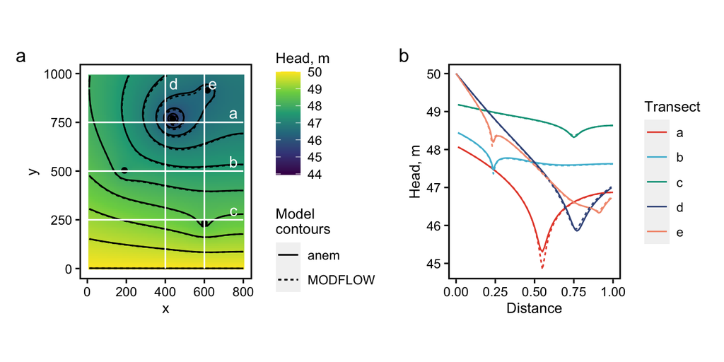

```r
p_validation <- p_head + p_transects + patchwork::plot_annotation(tag_levels = "a")

ggsave("modflow_validation.pdf",p_validation,path=mod_path,width=8,height=3.5)
p_validation
```